# Clase 18 - Guía Modelos Lineales Mixtos

Diplomado en Análisis de Datos con R e Investigación reproducible para Biociencias.

Dr. José A. Gallardo y Dra. María Angélica Rueda.

Pontificia Universidad Católica de Valparaíso  
jose.gallardo@pucv.cl

12 November 2022

### MODELOS LINEALES MIXTOS

Los modelos lineales mixtos (MLM) son una generalización del modelo lineal de regresión clásico, contemplando la posible existencia de observaciones correlacionadas (ej. Medidas repetidas en el mismo individuo) o con variabilidad heterogénea, vinculadas a la presencia de factores aleatorios.

**Efecto fijo**: Los efectos fijos solo estiman medias de las variables predictoras.

**Efecto aleatorio**: Los efectos aleatorios estiman varianzas.

Caracteristicas de un modelo lineal mixto (MLM)

1). El MLM está conformado por efectos fijos y efectos aleatorios.

2). La variable respuesta debe tener ditribución normal.

3). Existencia de observaciones correlacionadas.

4). Puede existir heterogeneidad de varianzas.

Incumplimiento de supuestos (1 y 3):

1. Hay observaciones correlacionadas.
2. Los residuos se distribuyen **normalmente**.
3. No hay homogeneidad de varianzas.

#### **Objetivos de aprendizaje**

Los objetivos de aprendizaje de esta guía son:

**1**. - Identificar efectos fijos y efectos aleatorios.

**3**. - Ajustar modelos lineales mixtos.

**3**. - Realizar gráficas avanzadas con ggplot2.

**4**. - Elaborar un reporte dinámico en formato pdf con **[Rmarkdown](https://rmarkdown.rstudio.com/)**.

### **Ejercicio 1.** Elaborar y configurar Reporte en formato .Rmd

Elabore un documento .Rmd y configure su reporte para exportar en .htlm. Instale solo los paquetes que utilice para el análisis de los datos.

```r
knitr::opts_chunk$set(echo = TRUE)
library(readxl)
library(ggplot2)
library(dplyr)
library(multcomp)
library(psych)
library(car)
library(nlme)
library(lme4)
library(readr)
library(lmtest)
library(sjPlot)
library(agriTutorial)
library(gridExtra)
```

Complete la información de metadatos con: Título: Reporte modelo lineal mixto. Nombre del autor: Su nombre.

Luego guarde inmediatamente su *script* como **script_modelos_lineales_mixtos_nombre_apellido.Rmd**.

Ejecute cada uno de los siguientes ejercicios en uno o más bloques de códigos diferentes. Sea ordenado y documente su reporte adecuadamente.

### **Ejercicio 2.** Estudio de caso: Datos de arroz (rice {agriTutorial})

En este estudio de caso trabajaremos con un set de datos de arroz (*rice*) del paquete de R **agriTutorial** (n=135). rice {agriTutorial}.

Las variables de estudio se describen a continuación: solo se consideraron algunas variables del set de datos para su descripción.

| **Variable** | **Descripción** | **Tipo de efecto/ variable** |
| --- | --- | --- |
| **Management** | Tres prácticas de manejo (minimum, optimum, intensive). | Efecto Fijo/ Factor de clasificación con 3 niveles. |
| **variety** | 3 Variedades (V1, V2, V3) | Efecto fijo/ Factor de clasificación con 3 niveles. |
| **yield** | Rendimiento (g) | Variable respuesta/ Cuantitativa continua. |
| **Replicate** | Replicas | Factor de clasificación con 3 niveles. |
| **Main** | Parcela principal | Factor de clasificación con 5 niveles. |

Este estudio de caso es un diseño experimental de arroz, donde se considera como variable respuesta la variable **yield**, como efectos fijos del modelo **management** y **variety** y como efecto aleatorio el efecto anidado de Replicate dentro de Main **Replicate:Main**. Los niveles de la variable Replicate son 3 y de la variable Main son 5; por lo tanto, el efecto anidado **Replicate:Main** tendrá 15 niveles, siendo considerado como efecto aleatorio en el modelo.

**a).** Importe el set de datos **data(rice)** del paquete **agriTutorial**. Explore el set de datos usando las funciones **head()**, **str()** y **summary()**.

```
##   yield nrate nitrogen Replicate management variety Main Sub
## 1 3.320     0        0        R1    Minimum      V1    1   1
## 2 6.101     0        0        R1    Minimum      V2    1   1
## 3 5.355     0        0        R1    Minimum      V3    1   1
## 4 3.766     0        0        R1    Optimum      V1    1   2
## 5 5.096     0        0        R1    Optimum      V2    1   2
## 6 7.442     0        0        R1    Optimum      V3    1   2
```

```
## 'data.frame':    135 obs. of  8 variables:
##  $ yield     : num  3.32 6.1 5.36 3.77 5.1 ...
##  $ nrate     : num  0 0 0 0 0 0 0 0 0 50 ...
##  $ nitrogen  : Factor w/ 5 levels "0","50","80",..: 1 1 1 1 1 1 1 1 1 2 ...
##  $ Replicate : Factor w/ 3 levels "R1","R2","R3": 1 1 1 1 1 1 1 1 1 1 ...
##  $ management: Factor w/ 3 levels "Minimum","Optimum",..: 1 1 1 2 2 2 3 3 3 1 ...
##  $ variety   : Factor w/ 3 levels "V1","V2","V3": 1 2 3 1 2 3 1 2 3 1 ...
##  $ Main      : Factor w/ 5 levels "1","2","3","4",..: 1 1 1 1 1 1 1 1 1 2 ...
##  $ Sub       : Factor w/ 3 levels "1","2","3": 1 1 1 2 2 2 3 3 3 1 ...
```

```
##      yield            nrate     nitrogen Replicate     management variety
##  Min.   : 3.132   Min.   :  0   0  :27   R1:45     Minimum  :45   V1:45
##  1st Qu.: 5.301   1st Qu.: 50   50 :27   R2:45     Optimum  :45   V2:45
##  Median : 6.509   Median : 80   80 :27   R3:45     Intensive:45   V3:45
##  Mean   : 6.554   Mean   : 76   110:27
##  3rd Qu.: 7.644   3rd Qu.:110   140:27
##  Max.   :10.360   Max.   :140
##  Main   Sub
##  1:27   1:45
##  2:27   2:45
##  3:27   3:45
##  4:27
##  5:27
##
```

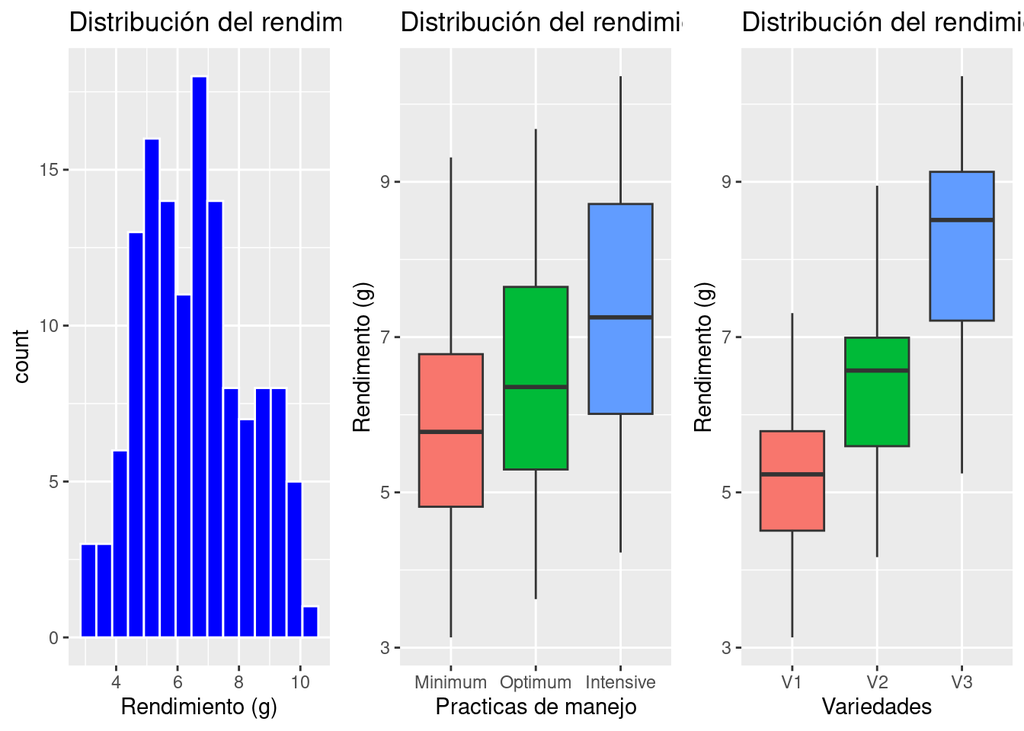

**c).** Elabore un gráfico de cajas y bigotes para la variable **yield** y como criterios de clasificación **management** y **variety**. Particione por **Replicate** usando la función *facet_wrap(~Replicate)*

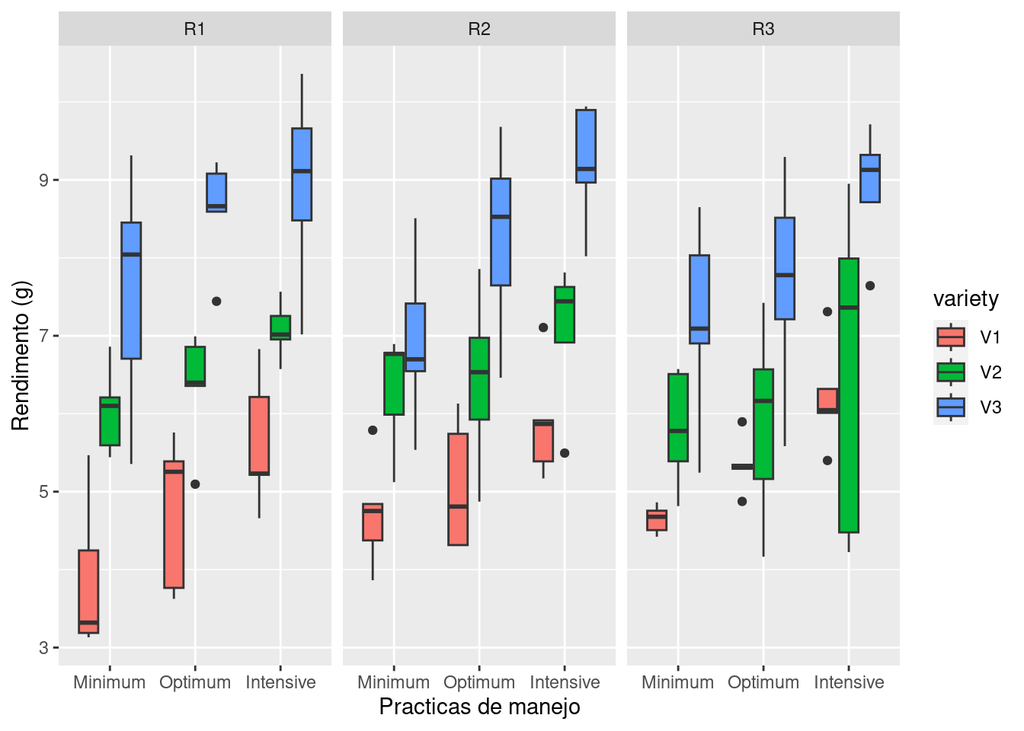

**d).** Realice el ajuste del siguiente modelo usando la función **lm(yield ~ management * variety, data = rice)**, donde los términos son los siguientes: variable respuesta **yield** y como factores de clasificación **management**, **variety** (use *) para considerar todos los efectos principales y de interacción. Llame al objeto rice.lm. Utilice el símbolo ~ para relacionar la variable respuesta con los factores de clasificación. Realice el summary del modelo ajustado.

Interprete los resultados del modelo ajustado y responda las siguientes preguntas:  
- ¿Los coeficientes estimados son estadísticamente significativos? - ¿Cuál es la bondad de ajuste del modelo $R^2$ ajustado?

```r
rice.lm <- lm(yield ~ management * variety, data = rice)
summary(rice.lm)
```

```
##
## Call:
## lm(formula = yield ~ management * variety, data = rice)
##
## Residuals:
##     Min      1Q  Median      3Q     Max
## -2.6854 -0.5421  0.1336  0.7045  2.0813
##
## Coefficients:
##                               Estimate Std. Error t value Pr(>|t|)
## (Intercept)                     4.4134     0.2528  17.461  < 2e-16 ***
## managementOptimum               0.6413     0.3574   1.794   0.0752 .
## managementIntensive             1.4990     0.3574   4.194 5.13e-05 ***
## varietyV2                       1.6416     0.3574   4.593 1.05e-05 ***
## varietyV3                       2.8193     0.3574   7.887 1.27e-12 ***
## managementOptimum:varietyV2    -0.4733     0.5055  -0.936   0.3509
## managementIntensive:varietyV2  -0.6436     0.5055  -1.273   0.2053
## managementOptimum:varietyV3     0.3068     0.5055   0.607   0.5450
## managementIntensive:varietyV3   0.2756     0.5055   0.545   0.5866
## ---
## Signif. codes:  0 '***' 0.001 '**' 0.01 '*' 0.05 '.' 0.1 ' ' 1
##
## Residual standard error: 0.9789 on 126 degrees of freedom
## Multiple R-squared:  0.6768, Adjusted R-squared:  0.6562
## F-statistic: 32.98 on 8 and 126 DF,  p-value: < 2.2e-16
```

**OTRA FORMA DE VER LOS RESULTADOS DEL SUMMARY CON FORMATO TABLA DE HTML**

```r
# PARA HACER TABLA CON RESULTADOS DEL OBJETO rice.lm
tab_model(rice.lm, show.se = TRUE, show.aic=TRUE)
```

|  | yield |  |  |  |
| --- | --- | --- | --- | --- |
| Predictors | Estimates | std. Error | CI | p |
| (Intercept) | 4.41 | 0.25 | 3.91 – 4.91 | **<0.001** |
| management [Optimum] | 0.64 | 0.36 | -0.07 – 1.35 | 0.075 |
| management [Intensive] | 1.50 | 0.36 | 0.79 – 2.21 | **<0.001** |
| variety [V2] | 1.64 | 0.36 | 0.93 – 2.35 | **<0.001** |
| variety [V3] | 2.82 | 0.36 | 2.11 – 3.53 | **<0.001** |
| management [Optimum] * variety [V2] | -0.47 | 0.51 | -1.47 – 0.53 | 0.351 |
| management [Intensive] * variety [V2] | -0.64 | 0.51 | -1.64 – 0.36 | 0.205 |
| management [Optimum] * variety [V3] | 0.31 | 0.51 | -0.69 – 1.31 | 0.545 |
| management [Intensive] * variety [V3] | 0.28 | 0.51 | -0.72 – 1.28 | 0.587 |
| Observations | 135 |  |  |  |
| R<sup>2</sup> / R<sup>2</sup> adjusted | 0.677 / 0.656 |  |  |  |
| AIC | 388.042 |  |  |  |

**e).** Pruebe los supuestos de independencia, homogeneidad de varianzas y normalidad usando pruebas estadísticas y gráficos.

- *Independencia*

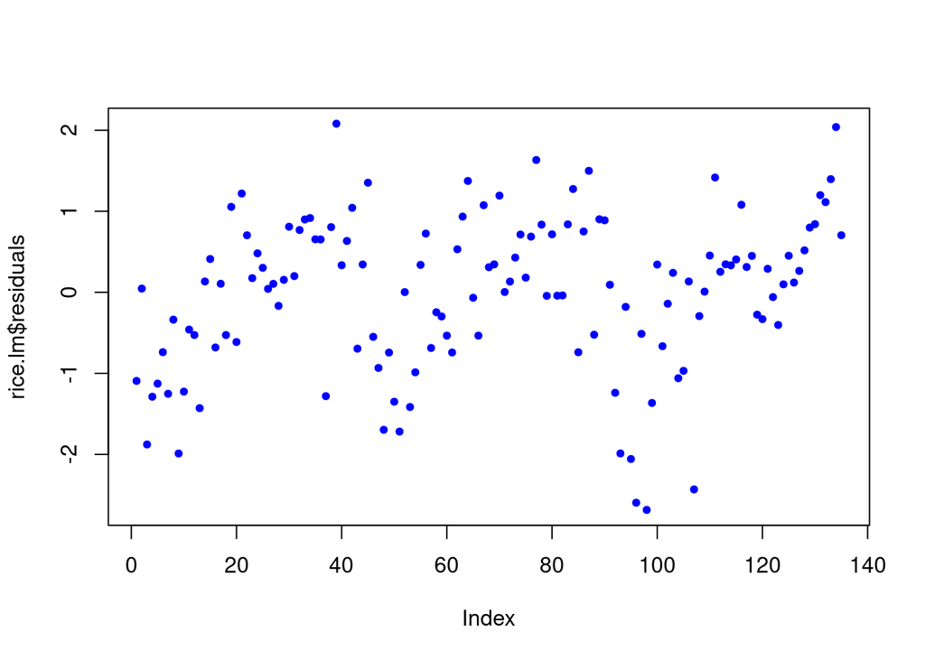

```r
plot(rice.lm$residuals, pch=20, col = "blue")
```

```r
dwtest(yield ~ management * variety, data = rice,
       alternative = c("two.sided"),
       iterations = 15)
```

```
##
##  Durbin-Watson test
##
## data:  yield ~ management * variety
## DW = 1.1178, p-value = 9.141e-07
## alternative hypothesis: true autocorrelation is not 0
```

- *Homogeneidad de varianzas*

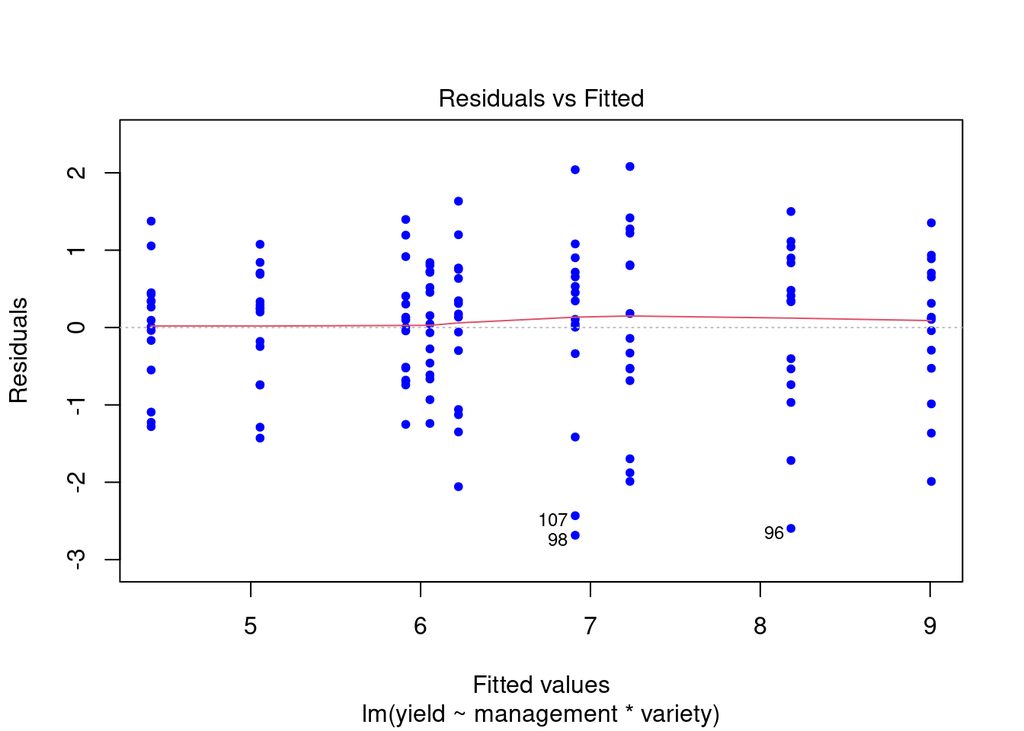

```r
plot(rice.lm,1, pch=20, col = "blue")
```

```r
bptest(rice.lm)
```

```
##
##  studentized Breusch-Pagan test
##
## data:  rice.lm
## BP = 12.97, df = 8, p-value = 0.1129
```

- *Normalidad*

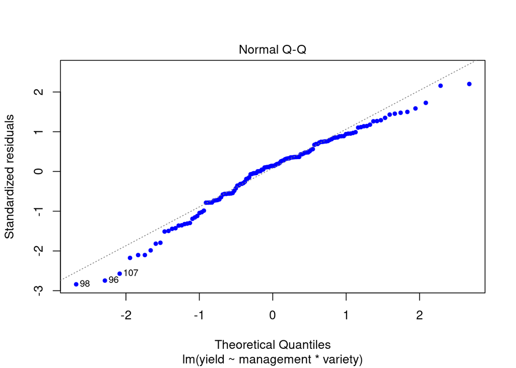

```r
plot(rice.lm,2, pch=20, col = "blue")
```

```r
lm_residuals <- residuals(object = rice.lm)
shapiro.test(x= lm_residuals)
```

```
##
##  Shapiro-Wilk normality test
##
## data:  lm_residuals
## W = 0.97513, p-value = 0.01416
```

¿Se cumplieron todos los supuestos evaluados anteriormente?

**f).** Realice el ajuste del siguiente modelo lineal mixto usando la función lmer(yield ~ management * variety + (1|Replicate:Main) , data = rice), donde los términos son los siguientes: variable respuesta **yield** y como efectos fijos los factores de clasificación **management**, **variety** (use *) para considerar todos los efectos principales y de interacción. Considere como efecto aleatorio (1|Replicate:Main). Llame al objeto rice.lmer. Utilice el símbolo ~ para relacionar la variable respuesta con los factores de clasificación. Realice el summary del modelo ajustado.

```r
rice.lmer <-  lmer(yield ~ management * variety + (1|Replicate:Main) , data = rice)
summary(rice.lmer)
```

```
## Linear mixed model fit by REML ['lmerMod']
## Formula: yield ~ management * variety + (1 | Replicate:Main)
##    Data: rice
##
## REML criterion at convergence: 321.9
##
## Scaled residuals:
##      Min       1Q   Median       3Q      Max
## -2.80834 -0.52875 -0.06551  0.59543  2.33486
##
## Random effects:
##  Groups         Name        Variance Std.Dev.
##  Replicate:Main (Intercept) 0.4769   0.6906
##  Residual                   0.4814   0.6938
## Number of obs: 135, groups:  Replicate:Main, 15
##
## Fixed effects:
##                               Estimate Std. Error t value
## (Intercept)                     4.4134     0.2528  17.461
## managementOptimum               0.6413     0.2533   2.531
## managementIntensive             1.4990     0.2533   5.917
## varietyV2                       1.6416     0.2533   6.480
## varietyV3                       2.8193     0.2533  11.128
## managementOptimum:varietyV2    -0.4733     0.3583  -1.321
## managementIntensive:varietyV2  -0.6436     0.3583  -1.796
## managementOptimum:varietyV3     0.3068     0.3583   0.856
## managementIntensive:varietyV3   0.2756     0.3583   0.769
##
## Correlation of Fixed Effects:
##             (Intr) mngmnO mngmnI vrtyV2 vrtyV3 mnO:V2 mnI:V2 mnO:V3
## mngmntOptmm -0.501
## mngmntIntns -0.501  0.500
## varietyV2   -0.501  0.500  0.500
## varietyV3   -0.501  0.500  0.500  0.500
## mngmntOp:V2  0.354 -0.707 -0.354 -0.707 -0.354
## mngmntIn:V2  0.354 -0.354 -0.707 -0.707 -0.354  0.500
## mngmntOp:V3  0.354 -0.707 -0.354 -0.354 -0.707  0.500  0.250
## mngmntIn:V3  0.354 -0.354 -0.707 -0.354 -0.707  0.250  0.500  0.500
```

**OTRA FORMA DE VER LOS RESULTADOS DEL SUMMARY CON FORMATO TABLA DE HTML**

|  | yield |  |  |  |
| --- | --- | --- | --- | --- |
| Predictors | Estimates | std. Error | CI | p |
| (Intercept) | 4.41 | 0.25 | 3.90 – 4.92 | **<0.001** |
| management [Optimum] | 0.64 | 0.25 | 0.14 – 1.14 | **0.013** |
| management [Intensive] | 1.50 | 0.25 | 1.00 – 2.00 | **<0.001** |
| variety [V2] | 1.64 | 0.25 | 1.14 – 2.14 | **<0.001** |
| variety [V3] | 2.82 | 0.25 | 2.32 – 3.32 | **<0.001** |
| management [Optimum] * variety [V2] | -0.47 | 0.36 | -1.18 – 0.24 | 0.189 |
| management [Intensive] * variety [V2] | -0.64 | 0.36 | -1.35 – 0.07 | 0.075 |
| management [Optimum] * variety [V3] | 0.31 | 0.36 | -0.40 – 1.02 | 0.394 |
| management [Intensive] * variety [V3] | 0.28 | 0.36 | -0.43 – 0.99 | 0.443 |
| Random Effects |  |  |  |  |
| σ<sup>2</sup> | 0.48 |  |  |  |
| τ<sub>00</sub> <sub>Replicate:Main</sub> | 0.48 |  |  |  |
| ICC | 0.50 |  |  |  |
| N <sub>Replicate</sub> | 3 |  |  |  |
| N <sub>Main</sub> | 5 |  |  |  |
| Observations | 135 |  |  |  |
| Marginal R<sup>2</sup> / Conditional R<sup>2</sup> | 0.663 / 0.831 |  |  |  |
| AIC | 343.946 |  |  |  |

**g).** Realice el plot del modelo ajustado anteriormente usando plot(rice.lmer).

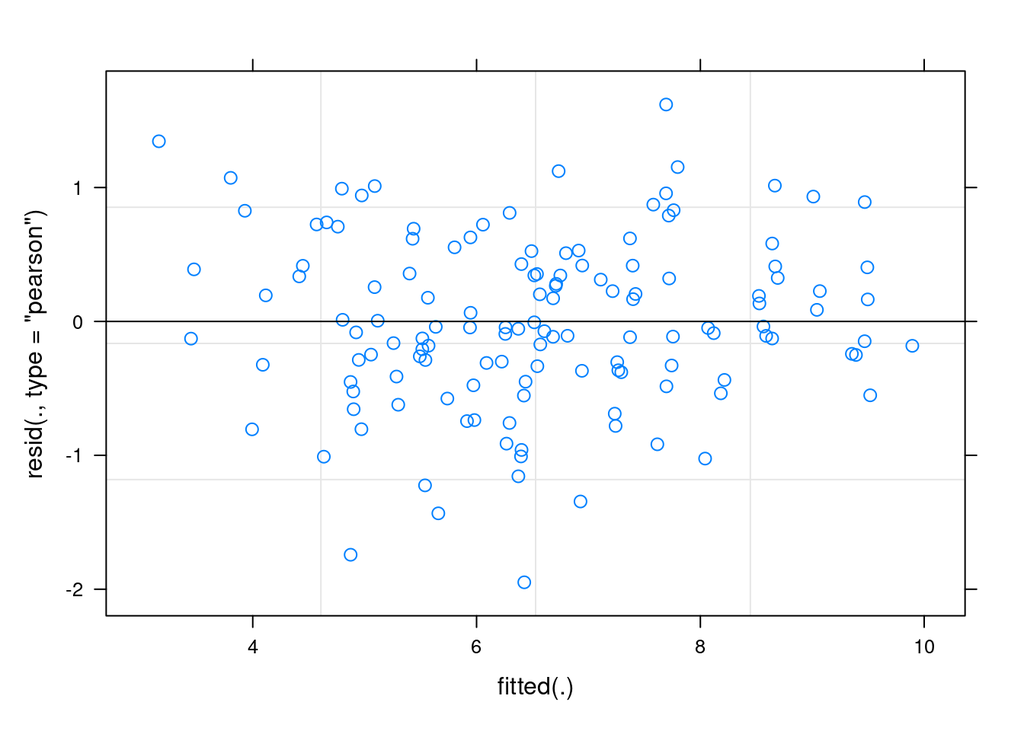

```r
plot(rice.lmer)
```

¿Qué observa del gráfico? se ve algún patrón o las observaciones son independientes?

**h).** Realice el gráfico QQplot y realice la prueba de Shapiro Wilks para ver si la distribución de los residuales del modelo lineal mixto **(del ítem f)** ajustado es normal.

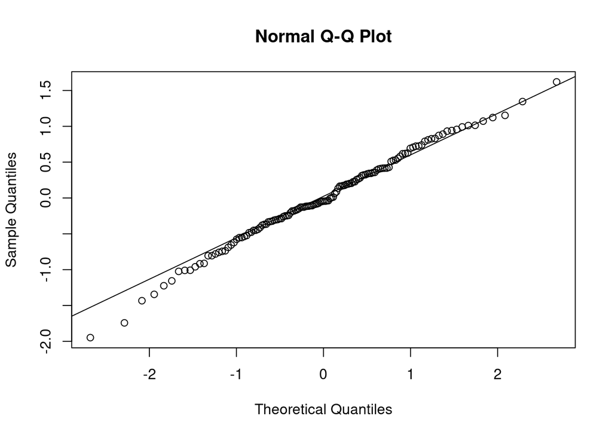

```r
qqnorm(resid(rice.lmer))
qqline(resid(rice.lmer))
```

```r
lm_residuals <- residuals(object = rice.lmer)
shapiro.test(x= lm_residuals)
```

```
##
##  Shapiro-Wilk normality test
##
## data:  lm_residuals
## W = 0.99294, p-value = 0.7409
```

¿Los residuales se distribuyen normal? ¿Hubo mejoría al ajustar el modelo lineal mixto?

**i).** Realice la comparación de modelos con las funciones AIC() y BIC().

- ¿Cuál es el mejor modelo?
- ¿Hubo mejoría al incorporar el efecto aleatorio de Replicate:Main?

```r
AIC(rice.lm, rice.lmer)
```

```
##           df      AIC
## rice.lm   10 388.0423
## rice.lmer 11 343.9461
```

```r
BIC(rice.lm, rice.lmer)
```

```
##           df      BIC
## rice.lm   10 417.0951
## rice.lmer 11 375.9041
```

```r
# El mejor modelo según los criterios de Akaike y BIC es el modelo lineal mixto; ya que presentan los valores más bajos de AIC y BIC.
# Al incorporar el efecto aleatorio de Replicate:Main se incremento el R2; ya que el modelo lineal de efectos fijos (que se ajustó con lm) presentó un valor de R2 ajustado de 0.656 y el R2 del modelo lineal mixto es de 0.831.
```

## ESTUDIO DE CASO: PIOJO EN SALMÓN

En este estudio de caso trabajaremos con un set de datos de salmón (n=354) publicado en la revista [JOURNAL OF EVOLUTIONARY BIOLOGY](https://onlinelibrary.wiley.com/doi/epdf/10.1111/jeb.13082)

La variable respuesta se denomina **Totalareadamage** y las variables predictoras **Status**, **Nbfemales**, **DaysPI** como efectos fijos y **Tank** como efecto aleatorio. La variable Status es cualitativa y Nbfemales, DaysPI son variables cuantiativas discretas.

En este estudio se evaluaron muchos tanques y se desea analizar que el comportamiento de cada tanque es diferente por lo que es necesario considerar el tanque como efecto aleatorio.

### **Ejercicio 3.** Exploratorio set de datos UGELVIK_et_al_2017.xlsx

Importe el set de datos **UGELVIK_et_al_2017.xlsx** y llame al objeto **datos_salmones**. Primero, omita los valores faltantes de la base de datos con la función na.omit(). Segundo, seleccione las variables **Tank**, **Status**, **Nbfemales**, **DaysPI** y **Totalareadamage** de la base de datos datos_salmones. Para finalizar,realice un análisis exploratorio de datos.

**a).** Resumen estadístico de todas las variables.

```r
datos_salmones <- read_excel("UGELVIK_et_al_2017.xlsx")
datos_salmones <- na.omit(datos_salmones)
datos_salmones <- datos_salmones[,c("Tank","Status", "Nbfemales", "DaysPI", "Totalareadamage")]
summary(datos_salmones)
```

```
##       Tank          Status            Nbfemales          DaysPI
##  Min.   : 1.00   Length:354         Min.   : 0.000   Min.   :  0.00
##  1st Qu.:14.00   Class :character   1st Qu.: 1.000   1st Qu.: 67.25
##  Median :30.00   Mode  :character   Median : 3.000   Median : 87.00
##  Mean   :29.75                      Mean   : 2.992   Mean   : 82.63
##  3rd Qu.:45.00                      3rd Qu.: 4.000   3rd Qu.:105.00
##  Max.   :60.00                      Max.   :13.000   Max.   :133.00
##  Totalareadamage
##  Min.   :  0.00
##  1st Qu.: 52.31
##  Median : 96.57
##  Mean   :124.29
##  3rd Qu.:165.11
##  Max.   :670.98
```

**b).** Transforme las variables Tank y Status en factores. Luego, pida el summary() de la base de datos datos_salmones.

```r
datos_salmones$Tank <- as.factor(datos_salmones$Tank)
datos_salmones$Status <- as.factor(datos_salmones$Status)
summary(datos_salmones)
```

```
##       Tank        Status      Nbfemales          DaysPI       Totalareadamage
##  4      :  9   Farmed:175   Min.   : 0.000   Min.   :  0.00   Min.   :  0.00
##  5      :  9   Wild  :179   1st Qu.: 1.000   1st Qu.: 67.25   1st Qu.: 52.31
##  7      :  9                Median : 3.000   Median : 87.00   Median : 96.57
##  23     :  9                Mean   : 2.992   Mean   : 82.63   Mean   :124.29
##  2      :  8                3rd Qu.: 4.000   3rd Qu.:105.00   3rd Qu.:165.11
##  8      :  8                Max.   :13.000   Max.   :133.00   Max.   :670.98
##  (Other):302
```

**c).** Histograma de la variable respuesta **Totalareadamage**.

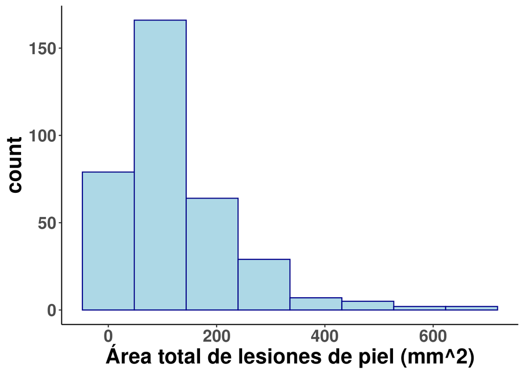

```r
ggplot(datos_salmones, aes(x=Totalareadamage))+
  geom_histogram(color="darkblue", fill="lightblue", bins = 8)+theme_classic()+theme(text = element_text(size=20,face="bold",colour="black"))+xlab("Área total de lesiones de piel (mm^2)")
```

**d).** Transforme la variable respuesta **Totalareadamage** usando la raíz cuadrada, use la función sqrt(Totalareadamage) y agregue esa variable al set de datos_salmones. Llame a esa variable rc_area_damage. Use la función mutate.

```r
datos_salmones <- datos_salmones %>%
                  mutate(rc_area_damage=sqrt(Totalareadamage))
```

**e).** Histograma de la variable respuesta transformada **rc_area_damage**.

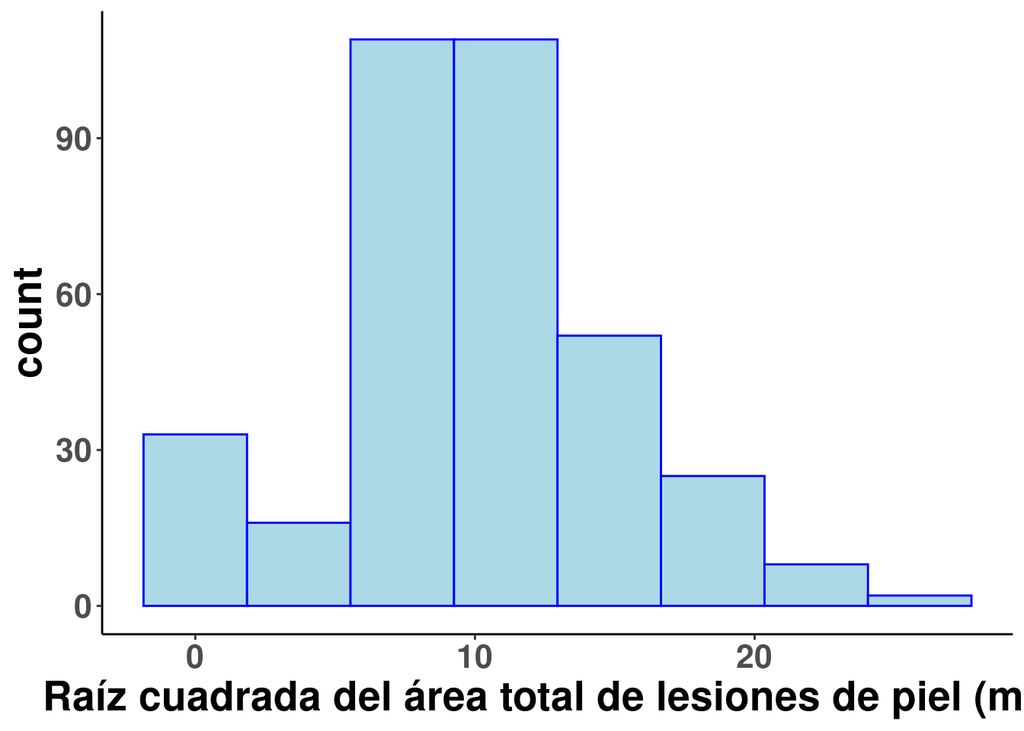

```r
ggplot(datos_salmones, aes(x=rc_area_damage))+
  geom_histogram(color="blue", fill="lightblue", bins = 8)+theme_classic()+theme(text = element_text(size=20,face="bold",colour="black"))+xlab("Raíz cuadrada del área total de lesiones de piel (mm)")
```

**f).** Realice el exploratorio de los datos

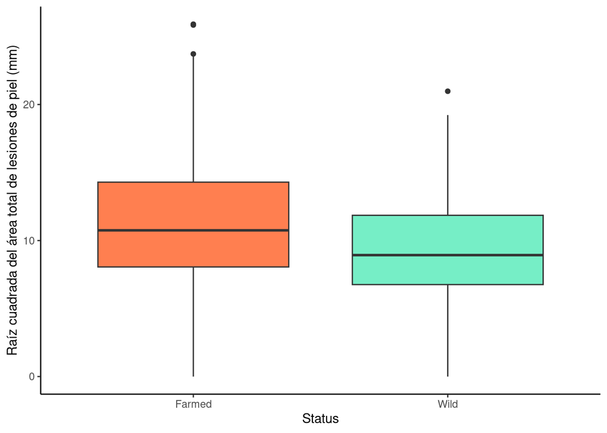

```r
ggplot(data = datos_salmones,aes(x= Status, y = rc_area_damage)) +
  geom_boxplot(fill=c("coral", "aquamarine2")) + theme(legend.position = 'right')+ theme_classic()+ylab("Raíz cuadrada del área total de lesiones de piel (mm)")
```

### **Ejercicio 4.** Modelo de efectos fijos

**a).** Ajuste el siguiente modelo de efectos fijo **lm(rc_area_damage ~ Status+ Nbfemales+ DaysPI, data = datos_salmones)** donde la variable respuesta sea **rc_area_damage** y como efectos fijos del modelo las variables **Status**, **Nbfemales** y **DaysPI**. Use la función **lm(rc_area_damage ~ Status+ Nbfemales+ DaysPI, data = datos_salmones)**. Además, realice el **summary()** del modelo ajustado.

Interprete los resultados del modelo ajustado y responda las siguientes preguntas:  
- ¿Los coeficientes estimados son estadísticamente significativos? - ¿Cuál es la bondad de ajuste del modelo $R^2$ ajustado?

```r
mod.1 <- lm(rc_area_damage ~ Status+ Nbfemales+ DaysPI, data = datos_salmones)

pander::pander(summary(mod.1), caption = "Modelo de efectos fijos")
```

|  | Estimate | Std. Error | t value | Pr(>\|t\|) |
| --- | --- | --- | --- | --- |
| **(Intercept)** | 5.334 | 0.7169 | 7.44 | 7.884e-13 |
| **StatusWild** | -1.581 | 0.4757 | -3.324 | 0.0009811 |
| **Nbfemales** | 0.6966 | 0.1048 | 6.646 | 1.155e-10 |
| **DaysPI** | 0.04025 | 0.007536 | 5.34 | 1.672e-07 |

Modelo de efectos fijos

| Observations | Residual Std. Error | $R^2$ | Adjusted $R^2$ |
| --- | --- | --- | --- |
| 354 | 4.402 | 0.2463 | 0.2399 |

**OTRA FORMA DE VER LOS RESULTADOS DEL SUMMARY CON FORMATO TABLA DE HTML**

```r
# PARA HACER TABLA CON RESULTADOS DEL OBJETO mod.1
tab_model(mod.1, show.se = TRUE, show.aic=TRUE)
```

|  | rc_area_damage |  |  |  |
| --- | --- | --- | --- | --- |
| Predictors | Estimates | std. Error | CI | p |
| (Intercept) | 5.33 | 0.72 | 3.92 – 6.74 | **<0.001** |
| Status [Wild] | -1.58 | 0.48 | -2.52 – -0.65 | **0.001** |
| Nbfemales | 0.70 | 0.10 | 0.49 – 0.90 | **<0.001** |
| DaysPI | 0.04 | 0.01 | 0.03 – 0.06 | **<0.001** |
| Observations | 354 |  |  |  |
| R<sup>2</sup> / R<sup>2</sup> adjusted | 0.246 / 0.240 |  |  |  |
| AIC | 2059.847 |  |  |  |

### **Ejercicio 5.** Modelo lineal mixto

**a).** Ajuste el siguiente modelo lineal mixto **lmer(rc_area_damage ~ Status+ Nbfemales+ DaysPI+ (1|Tank), data = datos_salmones)** donde la variable respuesta sea **rc_area_damage**, como efectos fijos del modelo las variables **Status**, **Nbfemales** y **DaysPI** y como efecto aleatorio tanque (Tank) **1|Tank**. Realice el **summary()** del modelo ajustado.

```r
mod.2 <- lmer(rc_area_damage ~ Status+ Nbfemales+ DaysPI+ (1|Tank), data = datos_salmones)
summary(mod.2)
```

```
## Linear mixed model fit by REML ['lmerMod']
## Formula: rc_area_damage ~ Status + Nbfemales + DaysPI + (1 | Tank)
##    Data: datos_salmones
##
## REML criterion at convergence: 1874.8
##
## Scaled residuals:
##     Min      1Q  Median      3Q     Max
## -2.4985 -0.5564 -0.0133  0.4603  4.1041
##
## Random effects:
##  Groups   Name        Variance Std.Dev.
##  Tank     (Intercept) 16.996   4.123
##  Residual              7.487   2.736
## Number of obs: 354, groups:  Tank, 58
##
## Fixed effects:
##              Estimate Std. Error t value
## (Intercept)  5.182130   0.886362   5.847
## StatusWild  -0.929802   1.078737  -0.862
## Nbfemales    1.550608   0.100147  15.483
## DaysPI       0.004304   0.005352   0.804
##
## Correlation of Fixed Effects:
##            (Intr) SttsWl Nbfmls
## StatusWild -0.630
## Nbfemales  -0.152  0.047
## DaysPI     -0.321 -0.008 -0.450
```

**OTRA FORMA DE VER LOS RESULTADOS DEL SUMMARY CON FORMATO TABLA DE HTML**

|  | rc_area_damage |  |  |  |
| --- | --- | --- | --- | --- |
| Predictors | Estimates | std. Error | CI | p |
| (Intercept) | 5.18 | 0.89 | 3.42 – 6.94 | **<0.001** |
| Status [Wild] | -0.93 | 1.08 | -3.09 – 1.23 | 0.394 |
| Nbfemales | 1.55 | 0.10 | 1.35 – 1.75 | **<0.001** |
| DaysPI | 0.00 | 0.01 | -0.01 – 0.01 | 0.423 |
| Random Effects |  |  |  |  |
| σ<sup>2</sup> | 7.49 |  |  |  |
| τ<sub>00</sub> <sub>Tank</sub> | 17.00 |  |  |  |
| ICC | 0.69 |  |  |  |
| N <sub>Tank</sub> | 58 |  |  |  |
| Observations | 354 |  |  |  |
| Marginal R<sup>2</sup> / Conditional R<sup>2</sup> | 0.366 / 0.806 |  |  |  |
| AIC | 1886.784 |  |  |  |

### **Ejercicio 6.** Comparación y selección de modelos

**a).** Realice la comparación de modelos con la función AIC().

- ¿Cuál es el mejor modelo?
- ¿Hubo mejoría al incorporar el efecto aleatorio de Tanque?

```r
AIC(mod.1, mod.2)
```

```
##       df      AIC
## mod.1  5 2059.847
## mod.2  6 1886.784
```

```r
# El mejor modelo según el criterio de Akaike es el modelo lineal mixto ya que es el que presenta el valor más bajo de AIC.
# Al incorporar el efecto aleatorio de Tanque se incremento el R2; ya que el modelo lineal de efectos fijos (que se ajustó con lm) presentó un valor de R2 ajustado de 0.240 y el R2 del modelo lineal mixto es de 0.806.
```